# Water Column and Sediment Methanogens & Methanotrophs in FPV Ponds

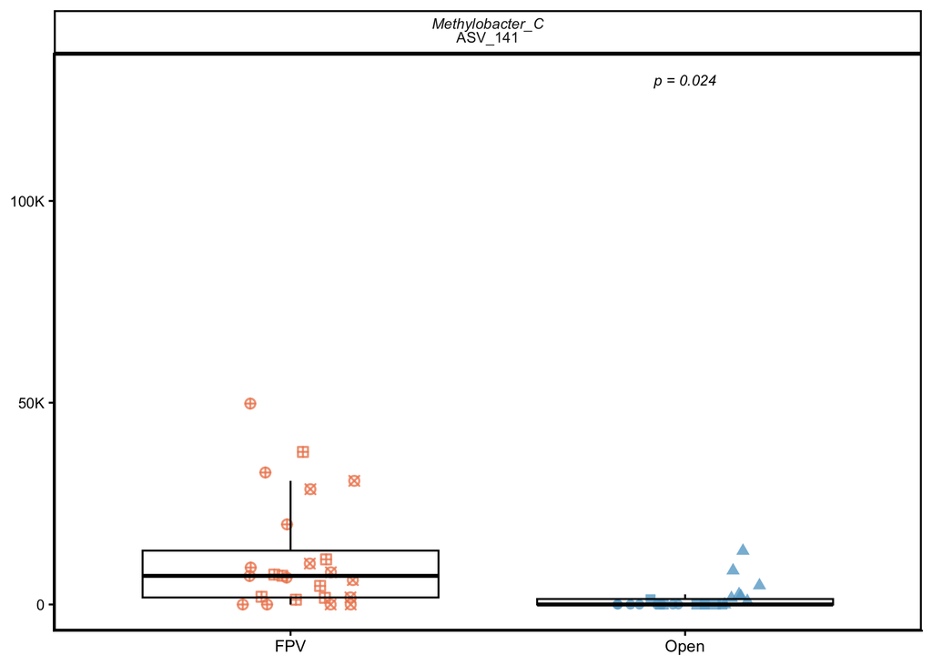

```r
# Make individual boxplots of the ASVs
ASV_141_methylobacterc <- diff_abund_df %>%
  dplyr::filter(ASV == "ASV_141") %>%
  ggplot(aes(x = solar_progress, y = total_abundance,
             color = solar_progress)) +
  geom_point(aes(shape = Pond),
             size = 2, alpha = 0.8, stroke = 0.8,
             position = position_jitterdodge(jitter.width = .5, dodge.width = .3)) +
  geom_boxplot(outlier.shape = NA, alpha = 0, color = "black", position = position_dodge(0.6)) +
  labs(color = "Treatment", y = "Water Column<br>Abundance (Cells mL<sup>-1</sup>)") +
  # ggh4x::facet_grid2(~ facet_label, scales = "free_y", nrow = 2,
  #                    strip = strip_vanilla(clip = "on")) +
  # facet_wrap2(~ facet_label, scales = "free_y", nrow = 2,
  #             strip = strip_themed(text_x = element_markdown(size = 9, face = "plain")))+
  #facet_wrap2(~italicized_label, scales = "free_y", nrow = 2, labeller = label_parsed) +
  ggh4x::facet_grid2(. ~ facet_label) +
  scale_color_manual(values = solar_colors) +
  scale_shape_manual(values = pond_shapes) +
  scale_y_continuous(
    #breaks = c(0, 1.5e5, 3e5),
    labels = label_number(scale_cut = cut_short_scale(), accuracy = 1)) +
  theme_classic() +
  # stat_compare_means(method = "wilcox.test",
  #                    #comparisons = list(c("FPV", "Open")),
  #                    label = "p.format",
  #                    #group.by = "combined_label",
  #                    size = 3,
  #                    label.y.npc = 0.9,
  #                    fontface = "italic",
  #                    #label.y = c(8000, 100000, 500000, 400000, 400000),
  #                    label.x = c(1.75, 1.75, 1.75)) +
  guides(
    #color = "none",
    color = guide_legend(
      #order = 1,
      ncol= 2,
      title.position = "top",
      title.hjust = 0.5,
      override.aes = list(size = 2.5)),
    shape = guide_legend(
      nrow= 2,
      byrow = TRUE,
      title.position = "top",
      title.hjust = 0.5,
      override.aes = list(size = 2.5))) +
  theme_classic() +
  theme(legend.position = "none",
        legend.spacing = unit(0, "cm"),
        plot.title = element_text(hjust = 0.5),
        panel.background =  element_rect(color = 'black', size = 1),
        panel.grid = element_blank(),
        legend.background = element_rect(fill = "transparent", color = NA), # remove legend box
        legend.key = element_rect(fill = "transparent", color = NA),
        legend.box.background = element_rect(fill='transparent', color = "transparent"), #transparent legend panel
        #legend.box.just = "center",
        #strip.background = element_rect(colour = NA, fill = 'transparent'),
        plot.background = element_rect(fill = "transparent", color="transparent"),
        legend.key.size = unit(0.4, "cm"),
        legend.spacing.x = unit(0.7, "cm"),
       legend.margin = margin(t = -5, unit = "pt"),
        strip.text = element_markdown(size = 8),
       #axis.title.y = element_markdown(size = 8, colour = "black"),
       axis.title.x = element_blank(),
      axis.title.y = element_blank(),
       axis.text.y = element_text(size = 8, colour = "black"),
       legend.title = element_text(size = 9, colour = "black"),
      legend.text = element_text(size = 8, colour = "black"))+
    annotate("text", x = 2, y = 1.3e5, label = "p = 0.024", size = 2.822,  fontface = "italic")
ASV_141_methylobacterc
```

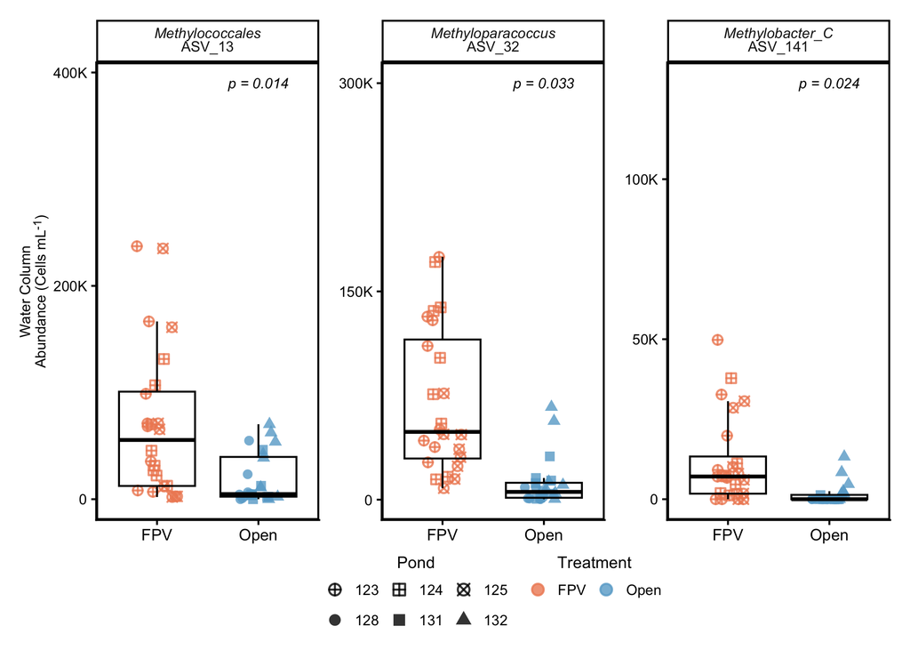

```r
# # extract legend
# legend <- cowplot::get_plot_component(ASV_13_methylococcales, "guide-box", return_all = TRUE) # can also do right
# legend_only <- legend[[3]]


fig4 <-  ASV_13_methylococcales +
  ASV_32_methyloparacoccus +
  ASV_141_methylobacterc +
  #plot_spacer() +
  plot_layout(ncol = 3, guides = "collect", widths = c(1,1,1)) &
  theme(
    legend.position = "bottom")
    #legend.justification = c(0,.2))
    #legend.box.margin = margin(2, 2, 2, 2.5))

fig4
```

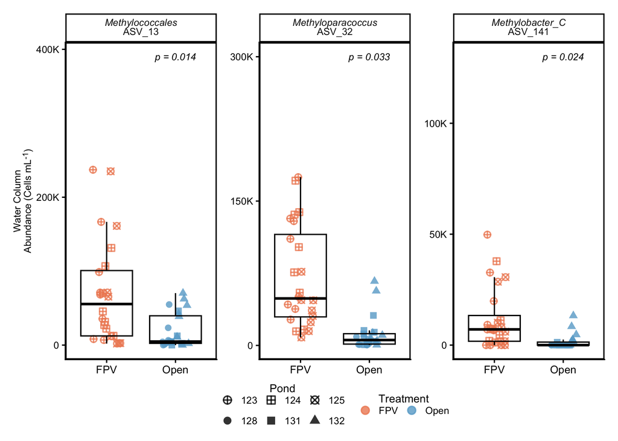

```r
p13  <- ASV_13_methylococcales + theme(legend.position = "bottom")
p32  <- ASV_32_methyloparacoccus + theme(legend.position = "bottom")
p141 <- ASV_141_methylobacterc + theme(legend.position = "bottom")

fig4 <- (p13 + p32 + p141) +
  plot_layout(ncol = 3, guides = "collect") &
  theme(
    legend.position = "bottom",
    legend.box = "horizontal",
    legend.box.just = "center",
    legend.direction = "horizontal",
    legend.title.position = "top",
    legend.title.align = 0.5,
    legend.title = element_text(margin = margin(b = 0, unit = "pt")))

  # theme(legend.position = "bottom", legend.box.just = "center", legend.box = "horizontal")
fig4
```

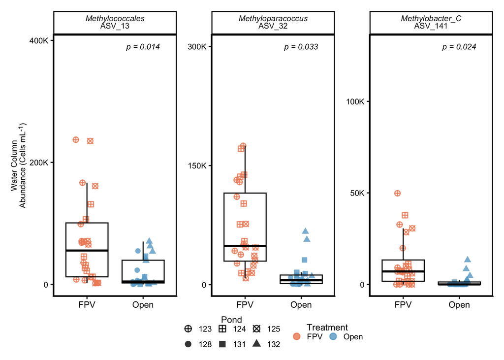

```r
fig4 <- fig4 &
  theme(
    legend.key.height = unit(0.35, "cm"),
    legend.key.width  = unit(0.35, "cm"),
    legend.spacing.x  = unit(0.4, "cm")
  )
fig4
```

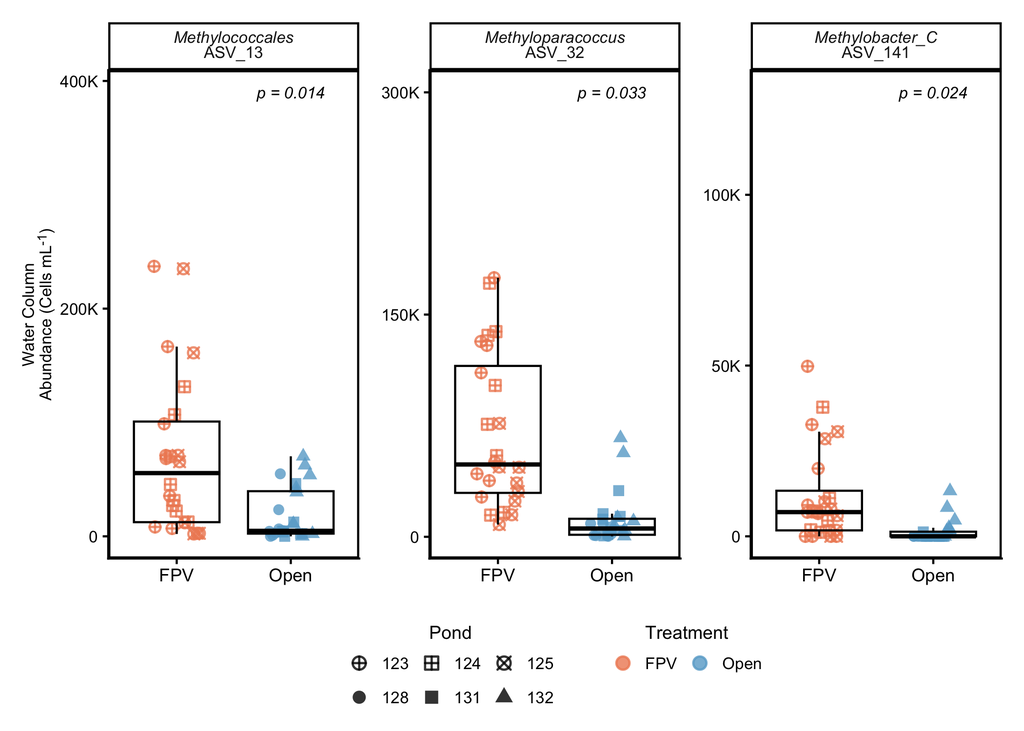

```r
## plot all together
fig4 <- ASV_13_methylococcales +
  ASV_32_methyloparacoccus +
  ASV_141_methylobacterc +
  #plot_spacer() +
  plot_layout(ncol = 3, guides = "collect", widths = c(1,1,1)) &
  theme(
    legend.position = "bottom",
    legend.spacing.x = unit(1, "cm"),
    legend.margin = margin(t = 8, unit = "pt"),
   # legend.justification = c(-30,.2),
   # legend.box.just = "center",
    legend.box.margin = margin(0, 0, 0, 0))

fig4
```

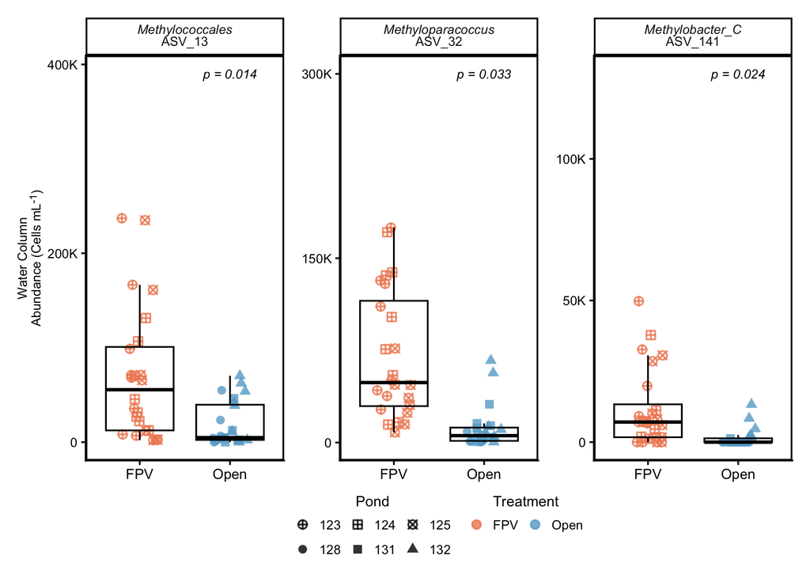

```r
# Save the plot
ggsave(fig4, width = 6.5, height = 4.5, dpi = 300,
        filename = "figures/Fig_4/Fig_4.png")


#or
library(ggplot2)
library(patchwork)

p13  <- ASV_13_methylococcales + guides(color = guide_none(), shape = guide_none())
p32  <- ASV_32_methyloparacoccus + guides(color = guide_none(), shape = guide_none())
p141 <- ASV_141_methylobacterc + guides(color = guide_none(), shape = guide_none())

fig4 <- (p13 + p32 + p141) +
  plot_layout(ncol = 3, guides = "collect") &
  theme(
    legend.position = "bottom",
    legend.box = "horizontal",
    #legend.box.just = "center",
    legend.box.margin = margin(2, 2, 2, 2),

    # make both guide boxes have identical sizing behavior
    legend.title.position = "top",
    legend.title.align = 0.5,
    legend.key.height = unit(0.35, "cm"),
    legend.key.width  = unit(0.35, "cm"),
    legend.spacing.y  = unit(0, "cm")
  ) &
  guides(
    color = guide_legend(title = "Treatment", nrow = 1, byrow = TRUE, title.position = "top", title.hjust = 0.5),
    shape = guide_legend(title = "Pond",      nrow = 2, byrow = TRUE, title.position = "top", title.hjust = 0.5)
  )

fig4
```

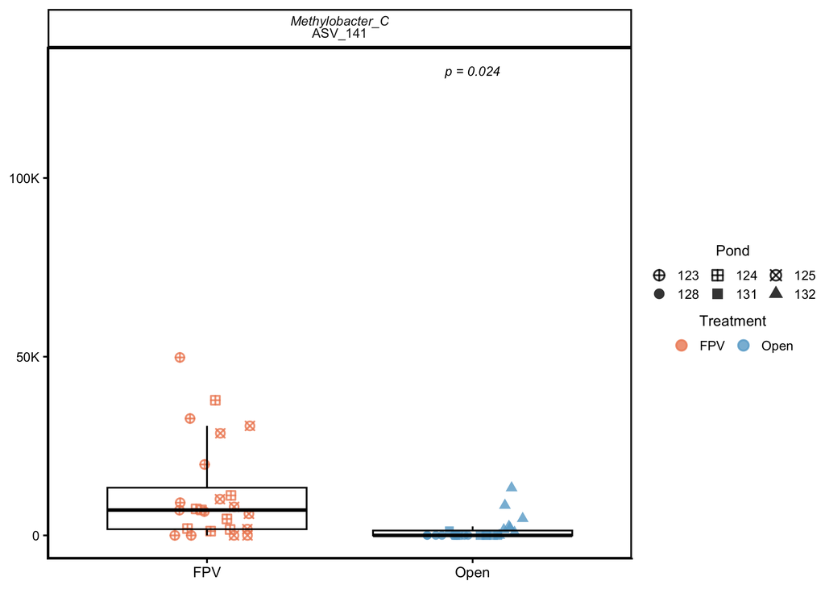

```r
library(cowplot)
library(patchwork)

# 1) Make one plot that DEFINITELY contains BOTH legends (color + shape),
#    and format it how you want the legend to look.
leg_plot <- ASV_141_methylobacterc +
  theme(legend.position = "right",
        legend.spacing = unit(.4, "cm"),
        #legend.key.size = unit(0.4, "cm"),
        legend.box.just = "center",
        legend.spacing.x = unit(1, "cm"));leg_plot
```

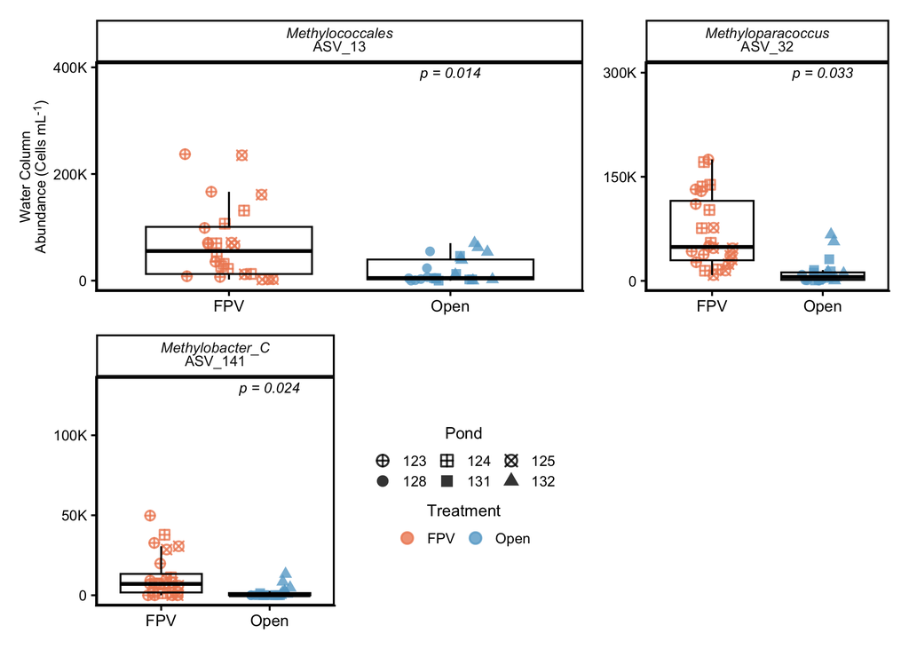

```r
       #legend.margin = margin(t = -5, unit = "pt"))
#+
  # guides(
  #   color = guide_legend(title = "Treatment", nrow = 2, byrow = TRUE, title.position = "top", title.hjust = 0.5),
  #   shape = guide_legend(title = "Pond",      nrow = 2, byrow = TRUE, title.position = "top", title.hjust = 0.5)


leg <- cowplot::get_legend(leg_plot)

# 2) Remove legends from the plots that go into the 2x2 grid
p13  <- ASV_13_methylococcales     + theme(legend.position = "none")
p32  <- ASV_32_methyloparacoccus   + theme(legend.position = "none")
p141 <- ASV_141_methylobacterc     + theme(legend.position = "none")

# 3) Put the legend in the empty cell (bottom-right)
fig4 <- (p13 + p32) +
        (p141 + cowplot::ggdraw(leg)) +
  plot_layout(widths = c(1,0.5));fig4
```

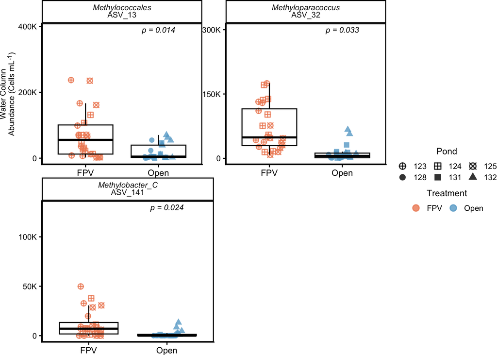

```r
library(patchwork)

p13  <- ASV_13_methylococcales     + theme(legend.position = "bottom")
p32  <- ASV_32_methyloparacoccus   + theme(legend.position = "bottom")
p141 <- ASV_141_methylobacterc     + theme(legend.position = "bottom")

fig4 <- (p13 + p32) /
        (p141 + guide_area()) +
  plot_layout(guides = "collect") &
  theme(
    legend.position = "right",        # collected legend will be drawn in guide_area
    legend.box.just = "center",
    plot.margin = margin(0, 0, 0, 0)
  )

fig4
```

### ASVs Less abundant in FPVs

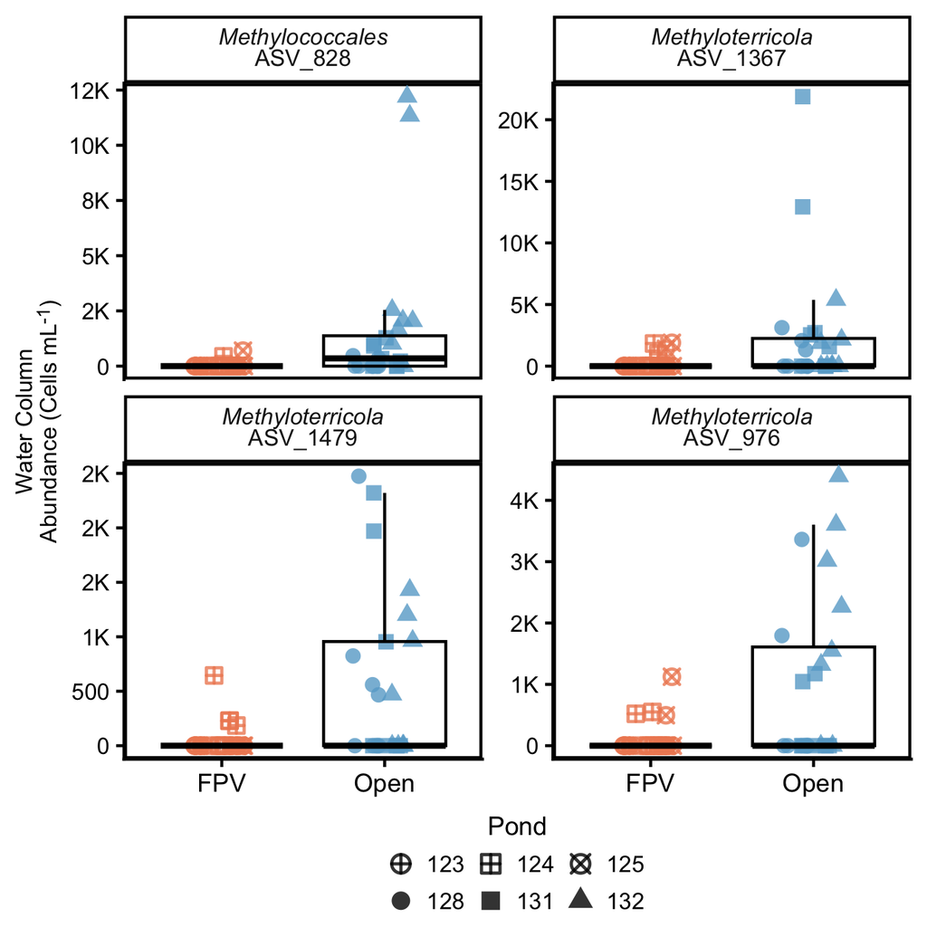

```r
asvs_lower_FPV_water <-
  water_ch4_asv_df_glom %>%
  dplyr::filter(ASV %in% c("ASV_1479", "ASV_976", "ASV_1367", "ASV_828")) %>%
  dplyr::group_by(
    JDate, Pond, Depth_Class, solar_progress,
    CH4_Cycler, Phylum, Class, Order, Family, Genus, ASV) %>%
  dplyr::summarise(
    total_abundance = sum(Abundance, na.rm = TRUE),
    .groups = "drop") %>%
  # as.data.frame() %>%
  dplyr::mutate(Genus = ifelse(ASV== "ASV_828", Order, Genus),
                facet_label = paste0("<i>", Genus, "</i><br>", ASV))

### Plot it
# Make Boxplots of the ASVs!
diffAbund_ASVsLowerFPV_boxplots <-
  asvs_lower_FPV_water%>%
  ggplot(aes(x = solar_progress, y = total_abundance,
             color = solar_progress)) +
  geom_point(aes(shape = Pond),
             size = 2, alpha = 0.8, stroke = 0.8,
             position = position_jitterdodge(jitter.width = .5, dodge.width = .3)) +
  geom_boxplot(outlier.shape = NA, alpha = 0, color = "black", position = position_dodge(0.6)) +
  labs(color = "Treatment", y = "Water Column<br>Abundance (Cells mL<sup>-1</sup>)") +
  ggh4x::facet_wrap2(~ facet_label, scales = "free_y", nrow = 2) +
  scale_color_manual(values = solar_colors) +
  scale_shape_manual(values = pond_shapes) +
  scale_y_continuous(labels = label_number(scale_cut = cut_short_scale(), accuracy = 1)) +
  theme_classic() +
  guides(
    color = "none",
    shape = guide_legend(
      nrow= 2,
      byrow = TRUE,
      title.position = "top",
      title.hjust = 0.5,
      override.aes = list(size = 2.5))) +
  theme_classic() +
  theme( #legend.position = c(0.75, 0.7),
    legend.position = "bottom",
        legend.spacing = unit(0, "cm"),
        plot.title = element_text(hjust = 0.5),
        panel.background =  element_rect(color = 'black', size = 1),
        panel.grid = element_blank(),
        legend.background = element_rect(fill = "transparent", color = NA), # remove legend box
        legend.key = element_rect(fill = "transparent", color = NA),
        legend.box.background = element_rect(fill='transparent', color = "transparent"), #transparent legend panel
        legend.box.just = "center",
        #strip.background = element_rect(colour = NA, fill = 'transparent'),
        plot.background = element_rect(fill = "transparent", color="transparent"),
        legend.key.size = unit(0.2, "cm"),
        legend.spacing.x = unit(0.2, "cm"),
       legend.margin = margin(t = -5, unit = "pt"),
        strip.text = element_markdown(size = 8),
       axis.title.y = element_markdown(size = 8, colour = "black"),
       axis.title.x = element_blank(),
       axis.text.y = element_text(size = 8, colour = "black"),
       legend.title = element_text(size = 9, colour = "black"),
      legend.text = element_text(size = 8, colour = "black")); diffAbund_ASVsLowerFPV_boxplots
```

### Sediment

First we are running this analysis with all methane cyclers.

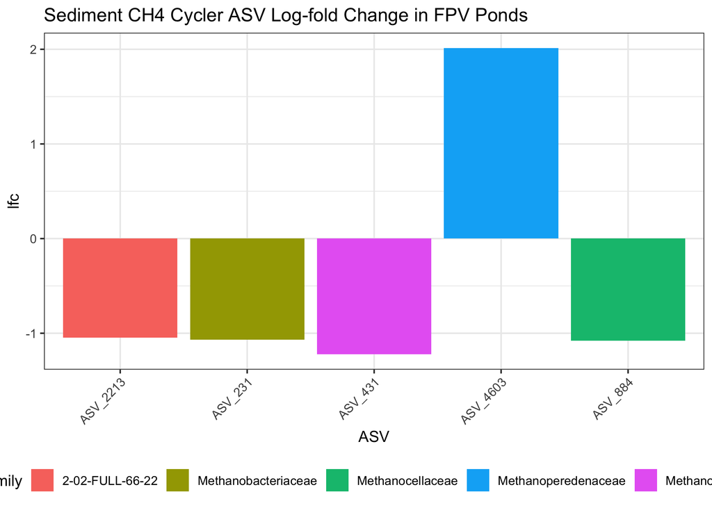

```r
# filter out for ASVs with zero variances; recommended to remove them as they are sparse and lowly abundant

# remove bad taxa
bad_taxa <- c("ASV_3924", "ASV_4747", "ASV_6182", "ASV_2152", "ASV_5977", "ASV_11602", "ASV_568", "ASV_10610", "ASV_8789", "ASV_15179", "ASV_5923", "ASV_8468", "ASV_3463", "ASV_2539", "ASV_2756", "ASV_4541", "ASV_7355", "ASV_2182", "ASV_5033", "ASV_2551", "ASV_4211", "ASV_3467", "ASV_1479", "ASV_1677", "ASV_7654", "ASV_13612", "ASV_6715", "ASV_9006", "ASV_8702", "ASV_9210")


scaled_sed_ch4_physeq_bc <-sed_ch4_cyclers_physeq %>%
  subset_taxa(., !(ASV %in% bad_taxa)) %>%
  prune_taxa(taxa_sums(.) > 0,.)


# relevel solar_progress
scaled_sed_ch4_physeq_bc@sam_data$solar_progress <- factor(scaled_sed_ch4_physeq_bc@sam_data$solar_progress, levels = c("No FPV", "FPV"))

# # run ancombc2 for all sediment methane cyclers
# sed_ch4_asv_output <- ancombc2(data = scaled_sed_ch4_physeq_bc,
#                                  tax_level = "ASV", # Test for each phylum
#                                  fix_formula = "solar_progress", # Use Comp_Group_Hier to estimate diff. abundance
#                                  p_adj_method = "fdr", # Adjust with Holm-Bonferroni correction; recommended by authors
#                                  pseudo_sens = TRUE, # Run sensitivity test to make sure taxa isn't sensitive to psuedo-count choice
#                                  prv_cut = 0.05, # Prevalence filter of 10%
#                                  group = NULL, # Use Comp_Group_Hier as groups when doing pairwise comparisons
#                                  struc_zero = FALSE, # Do not detect structural zeroes
#                                  alpha = 0.05, # Significance threshold of 0.05
#                                  n_cl = 5, # Use 5 threads
#                                  s0_perc = 0.05,
#                                  verbose = FALSE, # Don't print verbose output
#                                  global = FALSE, # Run a global test (sorta like an ANOVA to first find if a given ASV is sig diff)
#                                  pairwise = FALSE) # Run pairwise tests between groups (sorta like a post-hoc test like Tukey)


# save(sed_ch4_asv_output, file = "data/03_diff_abund/sed_ch4_asv_output.RData")

load("data/03_diff_abund/sed_ch4_asv_output.RData")


# plot ASV differential abundance
sed_ch4_fsp <- sed_ch4_asv_output$res %>%
  select(taxon, starts_with("lfc"), starts_with("diff"), starts_with("passed_ss")) %>%
  pivot_longer(cols = !taxon, names_to = "metric", values_to = "value") %>%
  separate_wider_delim(cols = metric, delim = "_", names = c("variable", "Comparison"), too_many = "merge") %>%
  mutate(Comparison = str_remove(Comparison, "\\(Intercept\\)")) %>%
  mutate(Comparison = str_remove(Comparison, "ss_")) %>%
  pivot_wider(id_cols = c("taxon","Comparison"), names_from = variable, values_from = value) %>%
  mutate(Comparison = str_remove(Comparison, "solar_progress"),
         Comparison = str_replace(Comparison, "_solar_progress", ";")) %>%
  separate_wider_delim(Comparison, delim = ";", names = c("Ref1", "Ref2"), too_few = "align_start") %>%
  filter(!is.na(Ref1) & Ref1 != "") %>%
  mutate(
    Ref2 = ifelse(is.na(Ref2), "Open", Ref2), # relevel with basegroup which is no solar
    Comparison = paste0(Ref2, " : ", Ref1)) %>%
  dplyr::filter(diff == 1, passed == 1, abs(lfc) > 1) %>% # play around with log fold change
  select(ASV = taxon, Comparison, lfc, passed)

# join by tax table
clean_sed_ch4 <-  sed_ch4_fsp %>% left_join(., as.data.frame(sed_ch4_cyclers_physeq@tax_table), by = "ASV")

# plot log fold changes
clean_sed_ch4 %>%
  ggplot(aes(x = ASV, y = lfc, fill = Family)) +
  geom_col() +
  #scale_fill_manual(values = phylum_colors) +
  theme_bw() +
  theme(axis.text.x = element_text(angle = 45, hjust = 1), legend.position = "bottom") +
  ggtitle("Sediment CH4 Cycler ASV Log-fold Change in FPV Ponds")
```

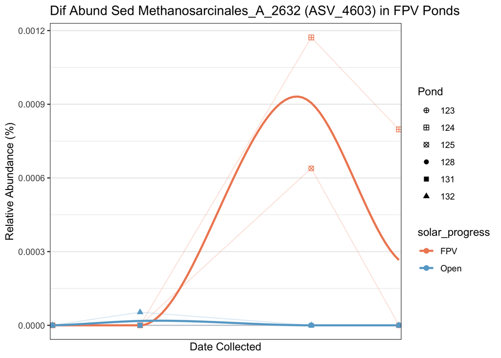

```r
# plot differentially abundant ASVs overtime


# methanogen = ASV_4603; Methanosarcinales_A_2632 order

# get metadata from water physeq
# metadata <- scaled_sed_ch4_physeq %>%
#   sample_data() %>%
#   data.frame()

sed_ch4_asv_df_glom <- sed_ch4_cyclers_physeq %>% # this phyloseq object has been transformed to relative abundance already
  tax_glom(taxrank = "ASV") %>%
  psmelt() %>%
  mutate(
    solar_progress = recode(solar_progress, "Solar" = "FPV", "No FPV" = "Open"))


# plot Methanogen overtime
sed_ch4_asv4603 <- sed_ch4_asv_df_glom %>%
  dplyr::filter(ASV == "ASV_4603") %>%
  dplyr::group_by(
    JDate, Pond, solar_progress) %>%
  dplyr::summarise(
    rel_abundance = sum(Abundance, na.rm = TRUE),
    .groups = "drop") %>%
  ggplot(aes(x = JDate, y = rel_abundance, color = solar_progress)) +
  geom_line(aes(group = interaction(Pond)),
            alpha = 0.2) +
  geom_smooth(aes(group = solar_progress), se = FALSE) +
  geom_point(aes(shape = Pond), size = 2) +
  scale_color_manual(values = solar_colors) +
  scale_shape_manual(values = pond_shapes) +
  labs(
    x = "Date Collected",
    y = "Relative Abundance (%)",
    title = "Dif Abund Sed Methanosarcinales_A_2632 (ASV_4603) in FPV Ponds"
  ) +
  theme(axis.text.x = element_text(angle = 30, hjust = 1, vjust = 1),
        legend.position = "bottom") +
  scale_x_discrete(guide = guide_axis(angle = 60)) +
  theme_bw()
sed_ch4_asv4603
```

There is a differentially abundant ASV Methanosarcinales_A_2632 that is increased in solar ponds! When we plot the abundance overtime this ASV is barely in the community but it is higher in solar ponds. Doesnt really feel worth it to report considering its a minor contribution to community.

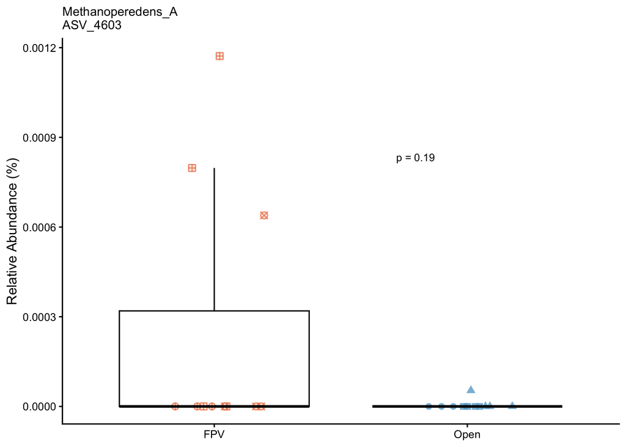

```r
sed_difAbund_plot <- sed_ch4_asv_df_glom %>%
  dplyr::filter(ASV == "ASV_4603") %>%
  dplyr::group_by(
    JDate, Pond, Depth_Class, solar_progress,
    CH4_Cycler, Phylum, Class, Order, Family, Genus, ASV) %>%
  dplyr::summarise(
    rel_abundance = sum(Abundance, na.rm = TRUE),
    .groups = "drop") %>%
  ggplot(aes(x = solar_progress, y = rel_abundance, color = solar_progress)) +
  geom_point(aes(shape = Pond),
             size = 2, alpha = 0.8, stroke = 0.8,
             position = position_jitterdodge(jitter.width = .5, dodge.width = .3)) +
  geom_boxplot(outlier.shape = NA, alpha = 0, color = "black",
               position = position_dodge(0.6)) +
  labs(color = "Treatment",
       y = "Relative Abundance (%)",
       title = "Methanoperedens_A \nASV_4603") +
  scale_color_manual(values = solar_colors) +
  scale_shape_manual(values = pond_shapes) +
  theme_classic() +
  ### ADD PVALUES
  stat_compare_means(method = "wilcox.test",
                     #comparisons = list(c("FPV", "Open")),
                     label = "p.format", # or "p.format" or "p.value"
                     #group.by = "combined_label",
                     size = 3,               # ⬅️ Font size
                     label.y.npc = 0.7,
                     #label.y = c(8000, 100000, 500000, 400000, 400000),
                     label.x = 1.75) +    # ⬅️ Manually set y position)  +
  guides(
    color = guide_legend(ncol = 2,override.aes = list(size = 2)),
    shape = guide_legend(ncol = 2, override.aes = list(size = 3))) +
  theme(legend.position = "none", #c(0.75, 0.7),
        axis.title.x = element_blank(),
        legend.title = element_text(size = 8),
        legend.text = element_text(size = 7),
        legend.key.size = unit(0.4, "cm"),
        legend.spacing.x = unit(0.2, "cm"),
        legend.margin = margin(t = -5, unit = "pt"),
        strip.text = element_text(size = 10),
        plot.title = element_text(size = 10)); sed_difAbund_plot
```

```r
# save the plot
# ggsave(sed_difAbund_plot, width = 3, height = 2, dpi = 300,
#         filename = "figures/Fig_S2/Fig_S2.png")
```

# Supplemental Figures

Now we will split this up by water and sediment methane cyclers.

## Water Methanogens

Cannot run methanogens on water column, data is too sparse

```r
# first lets filter our sed_ch4_cycler_physeq for methanogen or methanotroph
water_methanogens_physeq <- subset_taxa(water_ch4_cyclers_physeq, CH4_Cycler == "Methanogen") %>%
  prune_taxa(taxa_sums(.) > 0, .) # 66 ASVs

# it seems that there are so few methanogen asvs that i cant even calculate a distance matrix without removing those 0s. lets see who those are
samps <- sample_sums(water_methanogens_physeq)
which(samps == 0)

# further indication of how strongly methanotrophs shape water column
```

[output not shown]

## Water Methanotrophs

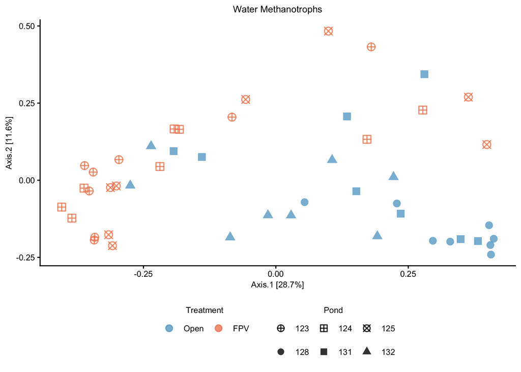

```r
# first lets filter our physeq for methanotroph
water_methanotrophs_physeq <- subset_taxa(water_ch4_cyclers_physeq, CH4_Cycler == "Methanotroph") %>%
  prune_taxa(taxa_sums(.) > 0, .) # 189 ASVs

# 2. methanotrophs

# Calculate Bray-Curtis Dissimilarity
water_methanotroph_BC_pcoa <-
  ordinate(
    physeq = water_methanotrophs_physeq,
    method = "PCoA",
    distance = "bray",
    binary = FALSE
  )


## NEW PLOT
#### Grab the data for the plot
water_methanotroph_df <-
  plot_ordination(
  physeq = water_methanotrophs_physeq,
  ordination = water_methanotroph_BC_pcoa,
  color = "solar_progress",
  shape = "Pond",
  justDF = TRUE)

# now lets mutate the columns
water_methanotroph_df <- water_methanotroph_df %>%
dplyr::mutate(
    solar_progress = recode(solar_progress, "FPV" = "FPV", "No FPV" = "Open")) # solar progress


### Now, plot Figure S3B: WATER METHANOTROPHS
figS3B_water_methanotroph_pcoa <-
  ggplot(data = water_methanotroph_df,
       aes(x = Axis.1,
           y = Axis.2,
           color = solar_progress,
           shape = Pond)) +
  geom_point(size = 3, alpha = 0.8, stroke = 0.8) +
  scale_shape_manual(values = pond_shapes) +
  scale_color_manual(values = solar_colors) +
  labs(color = "Treatment",
       shape = "Pond",
       x = "Axis.1 [28.7%]",
       y = "Axis.2 [11.6%]",
       title = "Water Methanotrophs") +
  guides(
    color = guide_legend(
      title.position = "top",
      title.hjust = 0.5,
      override.aes = list(size = 2.5)),
    shape = guide_legend(
      nrow = 2,
      byrow = TRUE,
      title.position = "top",
      title.hjust = 0.5,
      override.aes = list(size = 2.5))
  ) +
  theme_classic() +
  theme(legend.position = "bottom",
        #legend.spacing = unit(0, "cm"),
        legend.box.background = element_blank(),
        legend.title = element_text(size = 8),
        legend.text = element_text(size = 8),
        plot.title = element_text(hjust = 0.5, size = 9, colour = "black"),
        axis.text.x = element_text(size = 8, colour = "black"),
        axis.text.y = element_text(size = 8, colour = "black"),
        axis.title.x = element_text(size = 8, colour = "black"),
        axis.title.y = element_text(size = 8, colour = "black"))


# Show the plot
figS3B_water_methanotroph_pcoa
```

[figure not shown]

```r
# PCoA of sediments color by treatment shaped by pond
s3b_water_troph <- plot_ordination(
  physeq = water_methanotrophs_physeq,
  ordination = water_methanotroph_BC_pcoa,
  color = "solar_progress",
  shape = "Pond",
  title = "Sediment Methanotrophs") +
  geom_point(size = 5, alpha = 0.5, aes(color = solar_progress, fill = solar_progress, shape = Pond)) +
  scale_color_manual(values = solar_colors) +
  scale_fill_manual(values = solar_colors) +
  scale_shape_manual(values = pond_shapes) +
  guides(color = "none",
         fill = "none",
         shape = "none")+
  theme_classic()
s3b_water_troph
```